# 1st year Atelier Statistique - Mentored by Mr. Samer Azzabi

# Title of the Subject

Analysis of Credit Card Transactions for Early Detection of Defaults.

# Subject Description

This study focuses on the in-depth analysis of credit card holders’ behavior with the aim of early detection of potential signs of payment default. By examining spending habits, repayment patterns, and other financial behaviors, the objective is to identify predictive indicators that enable the assessment of default risk. The goal of this research is to facilitate a proactive approach in managing payment defaults, thereby offering financial institutions more accurate and faster solutions to evaluate and mitigate the inherent risks associated with credit card transactions. Work to be Done

• Data preprocessing (Outliers, missing values, data quality analysis) • Exploratory data analysis (Univariate analysis, bivariate analysis, Data visualization, …) • Variable transformation (Normalization, discretization, …) • Correlation analysis, analysis of variance, independence tests • Dashboard with RShiny.

# Information About the Dataset:

The dataset used is the “Default of Credit Card Clients Dataset” from UCI ML on Kaggle. This dataset contains information on payment defaults, demographic factors, credit data, payment history, and billing statements of credit card clients in Taiwan from April 2005 to September 2005.

```r
#Importing dependencies
library(ggplot2)
library(moments)
library(patchwork)
library(MASS)
library(DescTools)
library(bestNormalize)
```

```r
# Importing Data
data <- read.csv("./UCI_Credit_Card.csv")
head(data)
```

|  | ID | LIMIT_BAL | SEX | EDUCATION | MARRIAGE | AGE | PAY_0 | PAY_2 | PAY_3 | PAY_4 | PAY_5 | PAY_6 | BILL_AMT1 | BILL_AMT2 | BILL_AMT3 | BILL_AMT4 | BILL_AMT5 | BILL_AMT6 | PAY_AMT1 | PAY_AMT2 | PAY_AMT3 | PAY_AMT4 | PAY_AMT5 | PAY_AMT6 | default.payment.next.month |
| --- | --- | --- | --- | --- | --- | --- | --- | --- | --- | --- | --- | --- | --- | --- | --- | --- | --- | --- | --- | --- | --- | --- | --- | --- | --- |
| 1 | 1 | 20000 | 2 | 2 | 1 | 24 | 2 | 2 | -1 | -1 | -2 | -2 | 3913 | 3102 | 689 | 0 | 0 | 0 | 0 | 689 | 0 | 0 | 0 | 0 | 1 |
| 2 | 2 | 120000 | 2 | 2 | 2 | 26 | -1 | 2 | 0 | 0 | 0 | 2 | 2682 | 1725 | 2682 | 3272 | 3455 | 3261 | 0 | 1000 | 1000 | 1000 | 0 | 2000 | 1 |
| 3 | 3 | 90000 | 2 | 2 | 2 | 34 | 0 | 0 | 0 | 0 | 0 | 0 | 29239 | 14027 | 13559 | 14331 | 14948 | 15549 | 1518 | 1500 | 1000 | 1000 | 1000 | 5000 | 0 |
| 4 | 4 | 50000 | 2 | 2 | 1 | 37 | 0 | 0 | 0 | 0 | 0 | 0 | 46990 | 48233 | 49291 | 28314 | 28959 | 29547 | 2000 | 2019 | 1200 | 1100 | 1069 | 1000 | 0 |
| 5 | 5 | 50000 | 1 | 2 | 1 | 57 | -1 | 0 | -1 | 0 | 0 | 0 | 8617 | 5670 | 35835 | 20940 | 19146 | 19131 | 2000 | 36681 | 10000 | 9000 | 689 | 679 | 0 |
| 6 | 6 | 50000 | 1 | 1 | 2 | 37 | 0 | 0 | 0 | 0 | 0 | 0 | 64400 | 57069 | 57608 | 19394 | 19619 | 20024 | 2500 | 1815 | 657 | 1000 | 1000 | 800 | 0 |

# Content

• ID: ID of each client • LIMIT_BAL: Amount of credit granted in NT dollars (includes individual and family/supplementary credit) • SEX: Gender (1=male, 2=female) • EDUCATION: (1=graduate school, 2=university, 3=high school, 4=others, 5=unknown, 6=unknown) • AGE: Age in years • PAY_0: Repayment status in September 2005 (-1=pay duly, 1=payment delay of one month, 2=payment delay of two months, … 8=payment delay of eight months, 9=payment delay of nine months and more) • PAY_2: Repayment status in August 2005 (scale identical to the one above) • PAY_3: Repayment status in July 2005 (scale identical to the one above) • PAY_4: Repayment status in June 2005 (scale identical to the one above) • PAY_5: Repayment status in May 2005 (scale identical to the one above) • PAY_6: Repayment status in April 2005 (scale identical to the one above) • BILL_AMT1: Bill statement amount in September 2005 (NT dollar) • BILL_AMT2: Bill statement amount in August 2005 (NT dollar) • BILL_AMT3: Bill statement amount in July 2005 (NT dollar) • BILL_AMT4: Bill statement amount in June 2005 (NT dollar) • BILL_AMT5: Bill statement amount in May 2005 (NT dollar) • BILL_AMT6: Bill statement amount in April 2005 (NT dollar) • PAY_AMT1: Previous payment amount in September 2005 (NT dollar) • PAY_AMT2: Previous payment amount in August 2005 (NT dollar) • PAY_AMT3: Previous payment amount in July 2005 (NT dollar) • PAY_AMT4: Previous payment amount in June 2005 (NT dollar) • PAY_AMT5: Previous payment amount in May 2005 (NT dollar) • PAY_AMT6: Previous payment amount in April 2005 (NT dollar) • default.payment.next.month: Default payment (1=yes, 0=no)

# Structural check

```r
# Shape
print(paste("Shape:", paste(dim(data), collapse = " x ")))
```

```
[1] "Shape: 30000 x 25"
```

```r
# Data types
print("Data Types:")
```

```
[1] "Data Types:"
```

```r
sapply(data, class)
```

```
                        ID                  LIMIT_BAL                        SEX                  EDUCATION
                 "integer"                  "numeric"                  "integer"                  "integer"
                  MARRIAGE                        AGE                      PAY_0                      PAY_2
                 "integer"                  "integer"                  "integer"                  "integer"
                     PAY_3                      PAY_4                      PAY_5                      PAY_6
                 "integer"                  "integer"                  "integer"                  "integer"
                 BILL_AMT1                  BILL_AMT2                  BILL_AMT3                  BILL_AMT4
                 "numeric"                  "numeric"                  "numeric"                  "numeric"
                 BILL_AMT5                  BILL_AMT6                   PAY_AMT1                   PAY_AMT2
                 "numeric"                  "numeric"                  "numeric"                  "numeric"
                  PAY_AMT3                   PAY_AMT4                   PAY_AMT5                   PAY_AMT6
                 "numeric"                  "numeric"                  "numeric"                  "numeric"
default.payment.next.month
                 "integer"
```

```r
# Memory
print(paste("Data usage:", format(object.size(data), units = "MB"), collapse = "x"))
```

```
[1] "Data usage: 4.4 Mb"
```

```r
# Total of missin values
sum(is.na(data))
```

```
[1] 0
```

It appears that the data doesn’t contain any missing values, we’ll return to that later, let’s check for duplicate values

```r
# Checking for duplicate data
any(duplicated(data))
```

```
[1] FALSE
```

It seems the data doesn’t contain any duplicate rows

# Defining variable types

```r
data <- subset(data, select = -ID)
factor_vars <- c("SEX", "EDUCATION", "MARRIAGE", "PAY_0", "PAY_2", "PAY_3", "PAY_4",
                "PAY_5", "PAY_6")
quant_vars <- c("LIMIT_BAL", "AGE", "BILL_AMT1", "BILL_AMT2", "BILL_AMT3",
                "BILL_AMT4", "BILL_AMT5", "BILL_AMT6")
data[factor_vars] <- lapply(data[factor_vars], function(x) as.factor(x))
data$default.payment.next.month <- factor(
  data$default.payment.next.month,
  levels = c(0, 1),
  labels = c("Non-Defaut", "Defaut")
)
target <-"default.payment.next.month"
```

# Univariate Analysis

```r
# Function to detect outliers using IQR
detect_outliers_iqr <- function(x) {
  Q1 <- quantile(x, 0.25, na.rm = TRUE)
  Q3 <- quantile(x, 0.75, na.rm = TRUE)
  IQR <- Q3 - Q1
  lower_bound <- Q1 - 1.5 * IQR
  upper_bound <- Q3 + 1.5 * IQR
  return(x < lower_bound | x > upper_bound)
}
```

Let’s take a look at our variables one by one. LIMIT_BAL is the amount of credit granted in NT dollars.

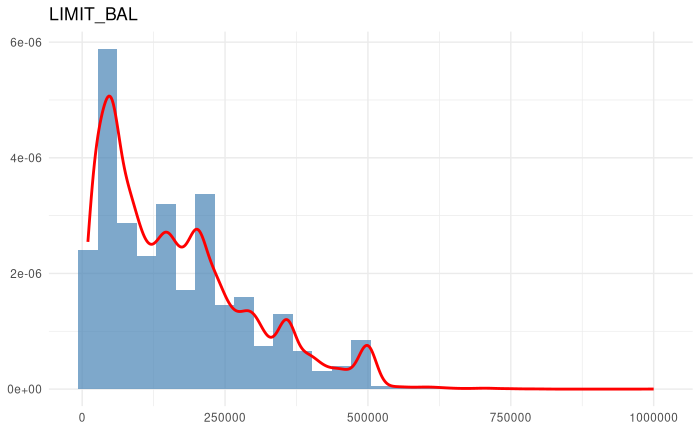

```r
ggplot(data, aes(x = LIMIT_BAL)) +
    geom_histogram(aes(y = after_stat(density)),
                   bins = 30, fill = "steelblue", alpha = 0.7) +
    geom_density(color = "red", linewidth = 1) +
    labs(title = "LIMIT_BAL", x = NULL, y = NULL) +
    theme_minimal()
```

We notice a positive skewness: most clients have credit limits below 500000NTD, while very few have higher credit limits. There are several possible reasons: •Higher-income or financially stronger customers may qualify for much larger credit limits. •Customers with a long history of responsible repayment may gradually receive higher limits. •Businesses, premium customers, or high-value customers may naturally receive much larger limits than ordinary customers. •Customers who consistently spend a lot may be given higher limits to accommodate their usage. •Lenders may assign limits based on perceived probability of default. Low-risk customers can receive substantially higher limits. •Long-standing customers may have earned increased limits over time. •A few extremely high values could represent corporate accounts, negotiated limits, or exceptional approvals. •The large values could also be data-entry errors or genuine statistical outliers.

```r
LIMIT_BAL_skewness = skewness(data$LIMIT_BAL)
round(LIMIT_BAL_skewness, digits = 3)
```

```
[1] 0.993
```

The skewness value is 0.993 which exists in the interval [0.5, 1], this confirms that the data is moderately positively skewed.

```r
ggplot(data, aes(x = LIMIT_BAL)) +
    geom_boxplot() +
    theme_classic()
```

[output not shown]

```r
outliers = detect_outliers_iqr(data$LIMIT_BAL)
print(paste("Outlier count:", sum(outliers)))
```

```
[1] "Outlier count: 167"
```

```r
print(paste("Outlier percentage:", sum(outliers)/nrow(data) * 100))
```

```
[1] "Outlier percentage: 0.556666666666667"
```

So only 0.5% of the population has a credit limit of over 500000NTD, which is a healthy percentage of outliers.

In general, the data is not suited for modeling, let’s try transforming it and seeing if that changes anything

# Box-Cox transformation

```r
bc <- boxcox(data$LIMIT_BAL)

# Optimal lambda
lambda <- bc$lambda
lambda
```

```
[1] 0.2673468
```

```r
if (abs(lambda) < 0.01) {
  data$LIMIT_BAL_boxcox <- log(data$LIMIT_BAL)
} else {
  data$LIMIT_BAL_boxcox <- (data$LIMIT_BAL^lambda - 1) / lambda
}
```

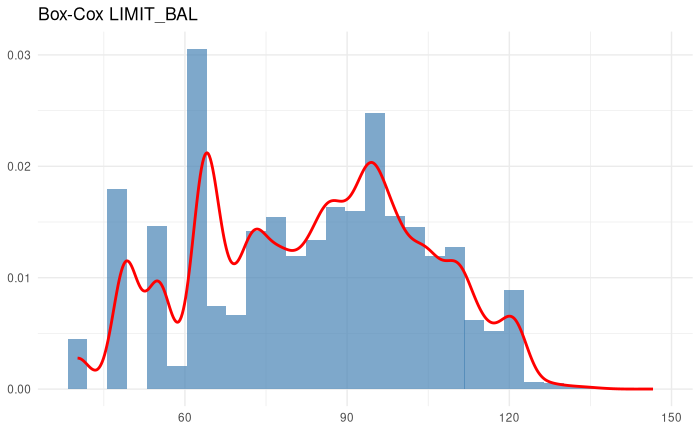

```r
ggplot(data, aes(x = LIMIT_BAL_boxcox)) +
    geom_histogram(aes(y = after_stat(density)),
                   bins = 30, fill = "steelblue", alpha = 0.7) +
    geom_density(color = "red", linewidth = 1) +
    labs(title = "Box-Cox LIMIT_BAL", x = NULL, y = NULL) +
    theme_minimal()
```

Let’s now look at the AGE variable

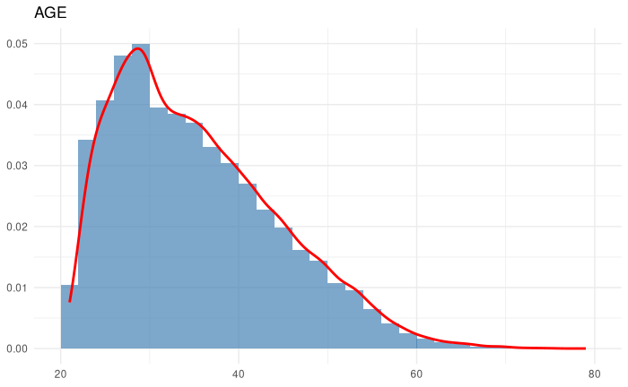

```r
ggplot(data, aes(x = AGE)) +
    geom_histogram(aes(y = after_stat(density)),
                   bins = 30, fill = "steelblue", alpha = 0.7) +
    geom_density(color = "red", linewidth = 1) +
    labs(title = "AGE", x = NULL, y = NULL) +
    theme_minimal()
```

We notice that the majority of the customer base is young (around 25-30), and this is normal, since in general, young people are the one actively using credit. There are also few older customers aged between 55 and 79, and these are legitimate older customers, not outliers

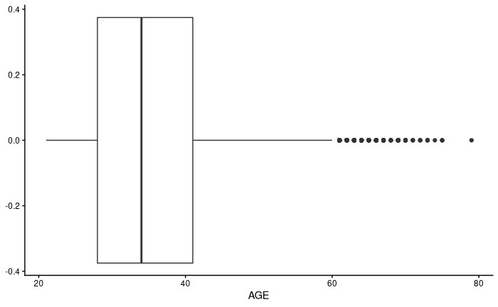

```r
ggplot(data, aes(x = AGE)) +
    geom_boxplot() +
    theme_classic()
```

The boxplot for AGE shows a right-skewed distribution, with the median age sitting around 34 years. The middle 50% of customers (the box) are concentrated between approximately 28 and 41 years old, with the bulk of the customer base being relatively young. The right tail extends toward older ages, and the cluster of individual points beyond 60 indicates that older customers (roughly 60 to 80 years old) are statistical outliers. However, these are legitimate older policyholders rather than data errors as pointed earlier, reflecting the rarity of elderly customers in this credit card dataset.

```r
# Create a list of plots
plots <- lapply(quant_vars, function(var) {
  ggplot(data, aes(x = .data[[var]])) +
    geom_histogram(aes(y = after_stat(density)),
                   bins = 30, fill = "steelblue", alpha = 0.7) +
    geom_density(color = "red", linewidth = 1) +
    labs(title = var, x = NULL, y = NULL) +
    theme_minimal()
})

# Combine plots in a grid
wrap_plots(plots, ncol = 2)
```

[output not shown]

```r
plots <- lapply(quant_vars, function(var){
  ggplot(data, aes(x = .data[[var]])) +
    geom_boxplot() +
    theme_classic()
})
wrap_plots(plots, ncol = 2)
```

[output not shown]

```r
skewness_values = sapply(data[, quant_vars], skewness, na.rm = TRUE)
skewness_df <- data.frame(
  Variable = quant_vars,
  Skewness = skewness_values,
  Interpretation = ifelse(abs(skewness_values) < 0.5, "Symmetric",
                   ifelse(abs(skewness_values) < 1, "Moderately Skewed", "Highy Skewed"))
)
skewness_df
```

[output not shown]

```r
# Bar plot of skewness values
ggplot(skewness_df, aes(x = reorder(Variable, Skewness), y = Skewness, fill = Skewness > 0)) +
  geom_bar(stat = "identity") +
  coord_flip() +
  geom_hline(yintercept = 0, linetype = "dashed") +
  labs(title = "Skewness of Quantitative Variables",
       x = "Variable", y = "Skewness") +
  theme_minimal() +
  scale_fill_manual(values = c("steelblue", "coral"),
                    labels = c("Negative", "Positive"),
                    name = "Direction")
```

[output not shown]

```r
# Detect outliers for all quantitative variables
outliers_list <- lapply(data[, quant_vars], detect_outliers_iqr)

# Count outliers per variable
outlier_counts <- sapply(outliers_list, sum, na.rm = TRUE)
outlier_percent <- outlier_counts / nrow(data) * 100

outlier_summary <- data.frame(
  Variable = quant_vars,
  Outliers = outlier_counts,
  Percent = round(outlier_percent, 2)
)
print(outlier_summary)
```

[output not shown]

```r
# Commencons par les histogrammes
for (var in quant_vars) {
  p <- ggplot(data, aes(x = .data[[var]])) +
    geom_histogram(aes(y = after_stat(density))) +
    geom_density() +
    theme_dark()
  print(p)
}
```

[output not shown]

#Vérification de l’équilibre des data

```r
ggplot(data, aes(default.payment.next.month)) +
  geom_bar(aes(y = after_stat(count / sum(count) * 100), fill = default.payment.next.month)) +
  scale_fill_manual(values = c("Non-Defaut" = "green", "Defaut" = "red")) +
  labs(y = "Percentage (%)", x = "Payment Defaut Status") +
  guides(fill = "none")  # Remove legend if you don't need it
```

[output not shown]

```r
percent <- prop.table(table(data$default.payment.next.month)) * 100
percent
```

[output not shown]